# day1_gsea_example

Prepare the data. Here we read three types of data:

1. the phenotype/condition data
2. the gene expression matrix
3. the gene set

The gene expression data is saved in `.gct` format and experimental condition/phenotype is saves in `.cls` format. Both formats are very simple, and you can try to write your own code to parse them.

Gene sets are saved in "`.gmt` format. It is also a simple format. You can try to parse it by your own.

```r
library(CePa)
condition = read.cls("P53.cls", treatment = "MUT", control = "WT")$label
expr = read.gct("P53_collapsed_symbols.gct")

ln = strsplit(readLines("c2.symbols.gmt"), "\t")
gs = lapply(ln, function(x) x[-(1:2)])
names(gs) = sapply(ln, function(x) x[1])

geneset = gs[["p53hypoxiaPathway"]]
```

This gene set is very small:

```r
length(geneset)
```

```
## [1] 20
```

Note here gene IDs in the expression matrix and in the gene sets are all gene symbols, thus no more adjustment needs to be done here.

The gene-level difference score is set as signal-to-noise ratios, which is:

$$\frac{\mu_1 - \mu_2}{\sigma_1 + \sigma_2}$$

We calculate the gene-level difference score in `s`:

```r
s = apply(expr, 1, function(x) {
    x1 = x[condition == "WT"]
    x2 = x[condition == "MUT"]
    (mean(x1) - mean(x2))/(sd(x1) + sd(x2))
})
```

Sort the gene scores from the highest to the lowest:

```r
s = sort(s, decreasing = TRUE)
```

Next we first implement the original GSEA method, which was proposed in Mootha et al., 2003.

```r
## original GSEA
l_set = names(s) %in% geneset
f1 = cumsum(l_set)/sum(l_set)

l_other = !names(s) %in% geneset
f2 = cumsum(l_other)/sum(l_other)
```

Here `f1` is the cumulative probability function of genes in the set and `f2` is the cumulative probability function of genes not in the set.

We first plot the CDF of two distributions.

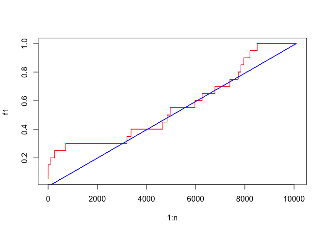

```r
n = length(s)
plot(1:n, f1, type = "l", col = "red")
lines(1:n, f2, col = "blue")
```

The reason why the blue locates almost on the diagonal is the gene set is very small.

Next the difference of cumulative probability (`f1 - f2`) at each position of the ranked gene list. Let’s call it “the GSEA plot”.

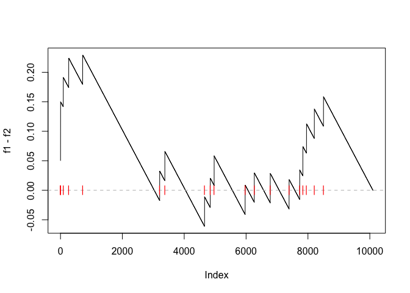

```r
plot(f1 - f2, type = "l")
abline(h = 0, lty = 2, col = "grey")
points(which(l_set), rep(0, sum(l_set)), pch = "|", col = "red")
```

The enrichment score (ES) defined as `max(f1 - f2)` is:

```r
es = max(f1 - f2)
es
```

```
## [1] 0.2294643
```

And the position in the “GSEA plot”:

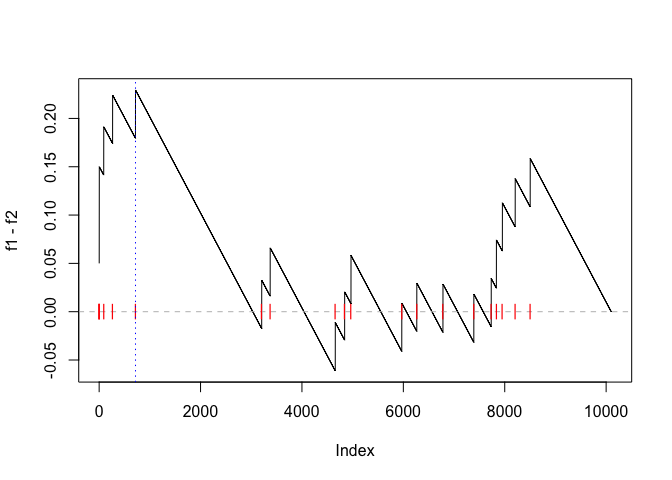

```r
plot(f1 - f2, type = "l")
abline(h = 0, lty = 2, col = "grey")
points(which(l_set), rep(0, sum(l_set)), pch = "|", col = "red")
abline(v = which.max(f1 - f2), lty = 3, col = "blue")
```

The statistic `es` actually is the Kolmogorov-Smirnov statistics, thus, we can directly apply the KS test:

```r
ks.test(which(l_set), which(l_other))
```

```
##
##  Two-sample Kolmogorov-Smirnov test
##
## data:  which(l_set) and which(l_other)
## D = 0.22946, p-value = 0.244
## alternative hypothesis: two-sided
```

However, we can see the p-value is not significant, this is because KS test is not a powerful test. Next we construct the null distribution by sample permutation.

In the next code chunk, the calculation of ES score is wrapped into a function, also we use `rowMeans()` and `rowSds()` to speed up the calculation of gene-level scores.

```r
library(matrixStats)
# expr: the complete expression matrix
# condition: the condition labels of samples
# cmp: a vector of two, cmp[1] - cmp[2] > 0 means up-regulation
# geneset: A vector of genes
calculate_es = function(expr, condition, cmp, geneset) {

    m1 = expr[, condition == cmp[1]]
    m2 = expr[, condition == cmp[2]]

    s = (rowMeans(m1) - rowMeans(m2))/(rowSds(m1) + rowSds(m2))

    s = sort(s, decreasing = TRUE)

    l_set = names(s) %in% geneset
    f1 = cumsum(l_set)/sum(l_set)

    l_other = !l_set
    f2 = cumsum(l_other)/sum(l_other)

    max(f1 - f2)
}
```

The ES score calculated by `calculate_es()`:

```r
es = calculate_es(expr, condition, cmp = c("WT", "MUT"), geneset = geneset)
es
```

```
## [1] 0.2294643
```

We randomly permute sample labels or we randomly permute `condition`. We do it 1000 times. The ES scores in null distributions are saved in `es_rand`.

```r
set.seed(123)
es_rand = numeric(1000)
for(i in 1:1000) {
    es_rand[i] = calculate_es(expr, sample(condition, length(condition)),
        cmp = c("WT", "MUT"), geneset = geneset)
}
```

p-value is calculated as the proportion of `es` being equal to or larger than in values in `es_rand`.

```r
sum(es_rand >= es)/1000
```

```
## [1] 0.129
```

The null distribution of ES:

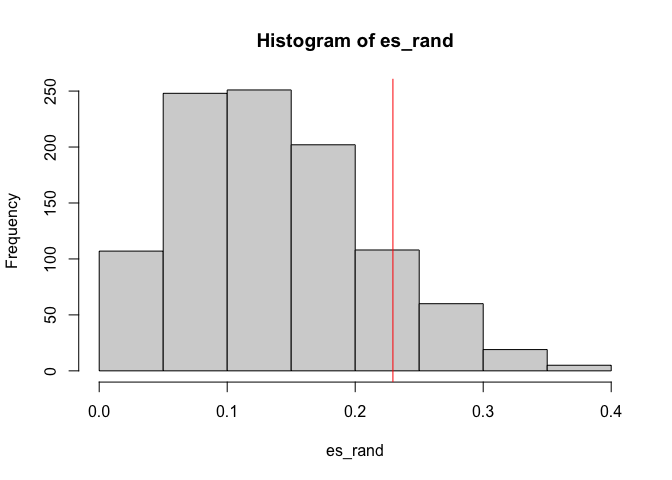

```r
hist(es_rand)
abline(v = es, col = "red")
```

Next we implement the improved GSEA (Subramanian et al., PNAS, 2005) where gene-level scores are taken as the weight.

We directly modify `calculate_es()` to `calculate_es_v2()` where there is only two lines new, which we highlight in the code chunk:

```r
calculate_es_v2 = function(expr, condition, cmp, geneset, plot = FALSE, power = 1) {

    m1 = expr[, condition == cmp[1]]
    m2 = expr[, condition == cmp[2]]

    s = (rowMeans(m1) - rowMeans(m2))/(rowSds(m1) + rowSds(m2))

    s = sort(s, decreasing = TRUE)

    l_set = names(s) %in% geneset
    # f1 = cumsum(l_set)/sum(l_set)  # <<-- the original line
    s_set = abs(s)^power   # <<-- here
    s_set[!l_set] = 0
    f1 = cumsum(s_set)/sum(s_set)  ## <<- here

    l_other = !l_set
    f2 = cumsum(l_other)/sum(l_other)

    if(plot) {
        plot(f1 - f2, type = "l")
        abline(h = 0, lty = 2, col = "grey")
        points(which(l_set), rep(0, sum(l_set)), pch = "|", col = "red")
        abline(v = which.max(f1 - f2), lty = 3, col = "blue")
    }

    max(f1 - f2)
}
```

Now we calculate the new ES score and make the GSEA plot:

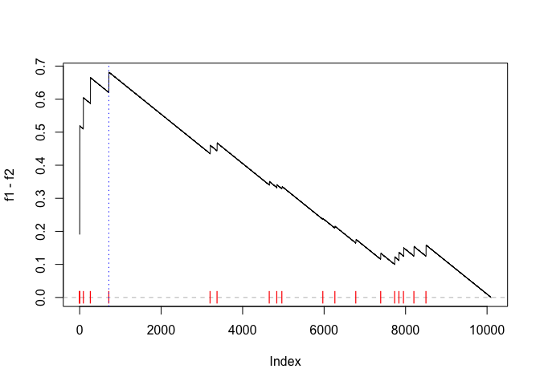

```r
es = calculate_es_v2(expr, condition, cmp = c("WT", "MUT"), plot = TRUE,
    geneset = geneset)
```

We can also check when `power = 0` and `power = 2`:

```r
par(mfrow = c(1, 2))
calculate_es_v2(expr, condition, cmp = c("WT", "MUT"), plot = TRUE, power = 0,
    geneset = geneset)  # same as the original GSEA
```

```
## [1] 0.2294643
```

```r
title("power = 0")
calculate_es_v2(expr, condition, cmp = c("WT", "MUT"), plot = TRUE, power = 2,
    geneset = geneset)
```

```
## [1] 0.8925371
```

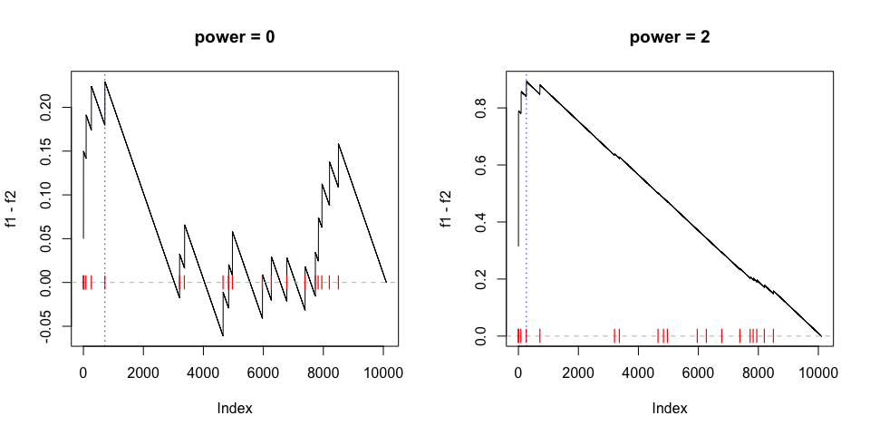

```r
title("power = 2")
```

```r
par(mfrow = c(1, 1))
```

Similarly, we randomly permute samples to obtain the null distribution of ES:

```r
es_rand = numeric(1000)
for(i in 1:1000) {
    es_rand[i] = calculate_es_v2(expr, sample(condition, length(condition)),
        cmp = c("WT", "MUT"), geneset = geneset)
}
```

The new p-value:

```r
sum(es_rand >= es)/1000
```

```
## [1] 0
```

And the null distribution of ES:

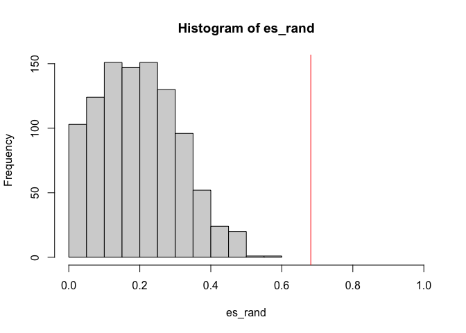

```r
hist(es_rand, xlim = c(0, 1))
abline(v = es, col = "red")
```

We can see the improved GSEA is more powerful than the original GSEA, because the original GSEA equally weights genes and the improved GSEA weights genes based on their differential expression, which increases the effect of diff genes. Let’s plot the weight of genes:

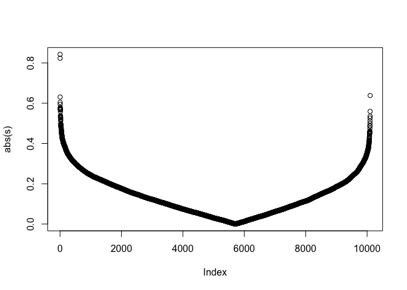

```r
plot(abs(s))
```

Null distribution can also be constructed by gene permutation. It is very easy to implement:

```r
# s should be sorted
calculate_es_v2_gene_perm = function(s, perm = FALSE, power = 1) {

    if(perm) {
        # s is still sorted, but the gene labels are randomly shuffled
        names(s) = sample(names(s), length(s))  ## <<- here
    }

    l_set = names(s) %in% geneset
    s_set = abs(s)^power
    s_set[!l_set] = 0
    f1 = cumsum(s_set)/sum(s_set)

    l_other = !l_set
    f2 = cumsum(l_other)/sum(l_other)

    max(f1 - f2)
}
```

Good thing of gene permutation is the gene-level scores only need to be calculated once and can be repeatedly used.

```r
m1 = expr[, condition == "WT"]
m2 = expr[, condition == "MUT"]

s = (rowMeans(m1) - rowMeans(m2))/(rowSds(m1) + rowSds(m2))
s = sort(s, decreasing = TRUE)  # must be pre-sorted
```

We calculate the null distribution of ES from gene permutation:

```r
es = calculate_es_v2_gene_perm(s)
es_rand = numeric(1000)
for(i in 1:1000) {
    es_rand[i] = calculate_es_v2_gene_perm(s, perm = TRUE)
}

sum(es_rand >= es)/1000
```

```
## [1] 0
```

The null distribution of ES from gene permutation:

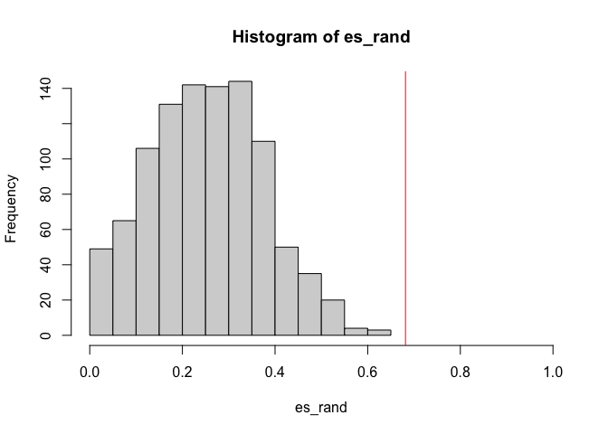

```r
hist(es_rand, xlim = c(0, 1))
abline(v = es, col = "red")
```